## STAT GU4243/GR5243 Spring 2017 Applied Data Science

### Project 3 Predictive analytics-model evaluation and selection

### - for poodle versus fried chickens (KFC?)

In this project, we will carry out **model evaluation and selection** for predictive analytics on image data. As data scientists, we often need to **evaluate** different modeling/analysis strategies and decide what is the best. Such decisions need to be supported by sound evidence in the form of *model assessment, validation and comparison*. In addition, we also need to **communicate our decision and supporting evidence** clearly and convincingly in an accessible fashion.

#### Challenge

For this project, you will receive [a set of 2000 greyscale images of poodle dogs and fried chickens](https://drive.google.com/open?id=0B0_uWEzqIWoENDB5RmZZWG5wTFU)[require logged into Columbia LionMail in your browser]. Here is an alternative [data link](https://drive.google.com/open?id=0B9sEbphmsGtERlNHMWR6WmxyRDg). These two links lead to **identical** data.

Your client is interested in creating an mobile AI program that accurately distinguish pictures of poodle dogs from pictures of fried chicken.

The portability of this AI program (holding storage and memory cost) and the computational efficiency (test running time cost) are of great concern to your client. This translates to a balance between the complexity of variable/features/models used and the predictive performance.

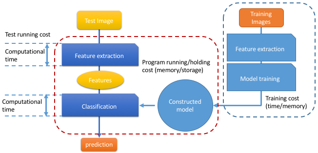

image

Assume that the **current practice** on your client side is just using boosted [decision stumps](https://en.wikipedia.org/wiki/Decision_stump) on [SIFT features](https://en.wikipedia.org/wiki/Scale-invariant_feature_transform). `R` pakcage [`gbm`](https://cran.r-project.org/package=gbm) can be used to implement this classifier.

#### Evaluation criteria

- Ease of reproducibility by the client (the instruction team)
  - are the codes for the proposed methods well annotated and documented?
  - can the analysis be re-run nearly automatically using the project’s `main.rmd`.
- Level of reproducibility
  - Can client derive the same evaluation conclusion as presented in the team’s final presentation?
  - How close are the reported performances (presentation and online) to the reproduced performances?
- Portability of proposed strategies
  - Computational speed for feature extraction and model training.
  - Computational speed for prediction.
  - Memory use for model training and prediction.- Presentation and organization
  - Is the presentation convincing about the intuition of the proposed strategies?
  - Is it supported by adequate and appropriate evidence?
  - Is the GitHub organized and prepared in a way that makes it easier for readers to understand the proposed strategies and its advantages and limitations?

*(More details will be posted as grading rubrics in courseoworks/canvas)*

#### Project details

For this project, you are to carry out a business feasibility evaluation project that try to propose a **feasible** improvement over the current practice in terms of running cost (storage, memory and time) **and** prediction accuracy.

##### Project time table.

- week 1 (2/24): introduction and project description
- week 2 (3/3): image processing and feature extraction
- week 3 (3/10): supervised learning and model assessment
- Final presentation (3/24)

##### Project learning support

Each week, we will give a tutorial in class and having live discussion and brainstorm sessions. The instruction team will join team discussions during class and online.

##### Final presentation

For presentation, the team should present their **proposal** for an improvement and support this proposal with evidence on

- Performance improvement;
- Running cost tradeoff;
- Supporting evidence on why the proposed strategies make sense, such as intuitiveness of the selected features etc.

The presentation can be technical but need to be accessible to your peer students in our class.

##### Platform requirement

We will reproduce your proposed model solution using `R`. This is a technical limitation of this project. Your classification model and model assessment must be conducted in `R`.

If you would like to use a tool such as tensorflow, you would need to include detailed installation steps in your RMarkdown file and use R wrappers.

You can use any tools for *feature engineering* as you will be processing features for the test images on 3/24.

- Your feature processing needs to be reasonably efficient as you will have only 30 minutes to process 1000 new images.
- Your feature program should have
  - a folder path as an input
  - and output a single RData file that contains feature R object as input for your `main.RMD` and `train.R` program.

##### Reproducibility requirement

Each team should organize the project repo on GitHub according to the structure of the starter codes.

[output not shown]

- In `data`, team members should individually save raw image data and a file that contains groundtruth labels for the images on their local computer. Currently there is a data folder with example hand-written zipcode images for the starter codes. You should **remove** it from your final repo. You shall not upload the images as these are copy-right protected materials.
- The `doc` folder should have documentations for this project, presentation files and other supporting materials. You should have a final `main.RMD` following the template given in the starter codes. Your `main.RMD` can assume that there is a data folder of raw images outside the root with subfolders corresponding to the training set and the test set.
- The `figs` folder contains figure files produced during the project and running of the codes.
- The `lib` folder contain R codes for the AI program. It should have the following files: `feature.R`, `train.R`, and `test.R`. The codes in the `lib` folder are not intended to be run directly but to be called from `main.RMD`.
- The `output` folder is the holding place for feature extracted, other intermediate and final results.

The instructional team will download each team’s GitHub repo and cross-examine each team’s proposal for reproducibility on the current dataset and for reliability using a different dataset.

##### Suggested team workflow

1. [wk1] Week 1 is the **planning** week. Read data description, fully understand the **project requirement**, and browse data and the starter codes.
2. [wk1] As a team, download the data, discuss data management need of this project, and try adapt the starter codes to a *subset* of images to a sense of computational burden of this project.
3. [wk1] As a team, read and brainstorm about possible lead on features.
4. [wk2] Based on outcomes from week 1 brainstorm sessions, start data cleaning (start early on this one!)
5. [wk2] Week 2 is the **exploration** week. Try different features and classifiers.
6. [wk2] It is ok to have 2-3 leads to explore at the beginning of week 2 but it is better to converge on a single direction by the end of week 2 (3/10).
7. [wk 3+4] Week 3/4 is program **evaluation** weeks. By 3/10 (the beginning of week 3), you should have a clear plan on what set of features to consider and what set of classifiers to consider. During the final week, there will be some serious model training, validation and testing, which is likely to take some time. (Start early!)
8. [wk 3+4] By 3/10, you should layout a to-do list and divide up tasks. Teams should work together and resolve any ambiguity about which team member should be doing what for this project. This is **extremly important** for this project due to the computational nature of this project.

##### Working together

- Setup a GitHub project folder with everyone listed as contributor. Everyone clones the project locally and create a local branch.
- The data is too big to be stored on GitHub. You can fork the repo to a local folder for this class or all your data science projects and have the data stored in “../data/” from root. Your project folder may look like

[output not shown]

- The team can work with subgroups of 2-3 work together more frequently than the entire team. However, everyone should check in regularly on group discussion online and changes in the GitHub folder.

##### Example starter codes

As example, you can find in the GitHub starter codes an example using handwritten zipcode data. We will give more examples during tutorials.